# HOMEWORK 2 (Intro to ML - Demo 2 / Data Pre-Processing & Regression)

### Packages

For the Homework we will need the packages:`caret`, `skimr`,`mice`

```r
library(caret)
library(skimr)
library(mice)
```

MICE (Multivariate Imputation via Chained Equations) creates multiple imputations as compared to a single imputation (such as mean) and takes care of uncertainty in missing values.

# 1. Airquality dataset

Variables Ozone: Mean ozone in parts per billion from 1300 to 1500 hours at Roosevelt Island Solar.R: Solar radiation in Langleys in the frequency band 4000–7700 Angstroms from 0800 to 1200 hours at Central Park Wind: Average wind speed in miles per hour at 0700 and 1000 hours at LaGuardia Airport Temp: Maximum daily temperature in degrees Fahrenheit at La Guardia Airport. Month Day

## Questions/Tasks to be done

1. Remove the outliers, delete all missing values & don’t normalize the data. Keep the data splitting with 70% / 30%.
   - compare the results to the one obtained in today’s class
   - what is you conclusion?

### Descriptive statistics

You may look at

1. Dimensions of the dataset
2. Types of variables
3. Statistical summary of all attributes

```r
# Structure of the dataframe
str(airquality)
```

```
'data.frame':   153 obs. of  6 variables:
 $ Ozone  : int  41 36 12 18 NA 28 23 19 8 NA ...
 $ Solar.R: int  190 118 149 313 NA NA 299 99 19 194 ...
 $ Wind   : num  7.4 8 12.6 11.5 14.3 14.9 8.6 13.8 20.1 8.6 ...
 $ Temp   : int  67 72 74 62 56 66 65 59 61 69 ...
 $ Month  : int  5 5 5 5 5 5 5 5 5 5 ...
 $ Day    : int  1 2 3 4 5 6 7 8 9 10 ...
```

We have a dataset with 153 observations, where we see also some missing values, and 6 variables.

**Which ML model do we use**

We use Regression, because input and output variables are numeric.

The `skimr::skim()` shows us a Dataframe including descriptive stats of each of the columns.

```r
skimmed <- skim(airquality)
skimmed
```

```
-- Data Summary ------------------------
                           Values
Name                       airquality
Number of rows             153
Number of columns          6
_______________________
Column type frequency:
  numeric                  6
________________________
Group variables            None

-- Variable type: numeric ------------------------------------------------------------------------------------------------------------------------------
# A tibble: 6 x 11
  skim_variable n_missing complete_rate   mean    sd    p0   p25   p50   p75  p100 hist
* <chr>             <int>         <dbl>  <dbl> <dbl> <dbl> <dbl> <dbl> <dbl> <dbl> <chr>
1 Ozone                37         0.758  42.1  33.0    1    18    31.5  63.2 168   ▇▃▂▁▁
2 Solar.R               7         0.954 186.   90.1    7   116.  205   259.  334   ▅▃▅▇▅
3 Wind                  0         1       9.96  3.52   1.7   7.4   9.7  11.5  20.7 ▂▇▇▃▁
4 Temp                  0         1      77.9   9.47  56    72    79    85    97   ▂▃▇▇▃
5 Month                 0         1       6.99  1.42   5     6     7     8     9   ▇▇▇▇▇
6 Day                   0         1      15.8   8.86   1     8    16    23    31   ▇▇▇▇▆
```

Here we see that there are 37 missing values for Ozone and 7 missing values for Solar.R and how the data is roughly distributed

The boxplot function (see below) shows us also some outliers within the ozone and wind columns

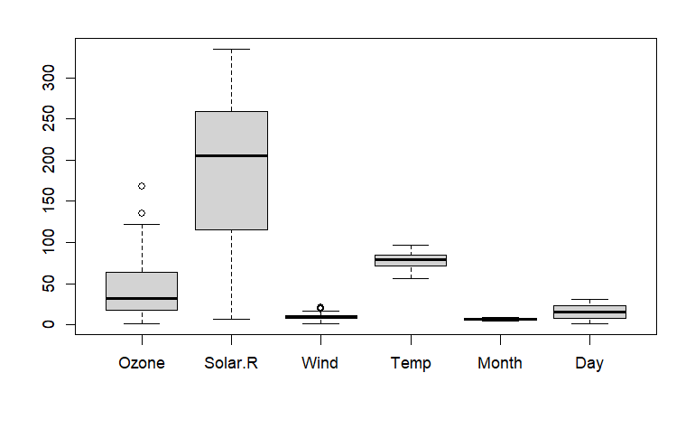

```r
  boxplot(airquality)
```

Here we can see the interaction in the scatter plot between the different variables:

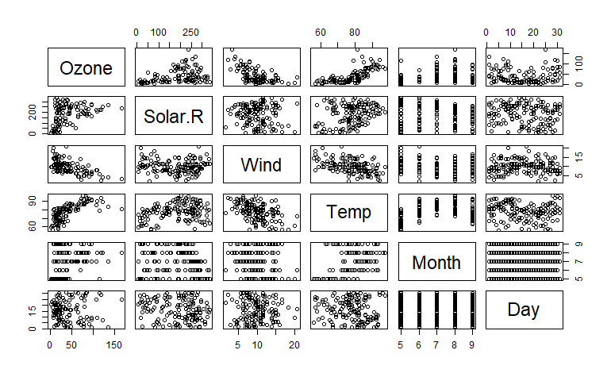

```r
pairs(airquality)
```

especially for: - `Temp` with `Wind` -> neg. correlated  
- `Ozone` with `Wind` => non-linear -> neg. correlated  
- `Ozone` with `Temp` => non-linear -> pos. correlation  
- `Temp` with `Month`

# Data pre-processing

Now for this task 1 we need to:

1. Outlier detection -> and removing
2. Missing value treatment -> deleting all missing values
3. Normalization -> no normalization

### Outlier detection

outliers lie outside 1.5 * IQR, which we can see in the boxplot.

```r
par(mfrow=c(2,2))
boxplot(airquality$Ozone,col = "grey",main = "Boxplot of Ozone",outcol="Blue",outpch=19,boxwex=0.7,range = 1.5)
hist(airquality$Ozone,col = "grey",main = "Histogram of Ozone", xlab = "Observations",breaks = 15)
```

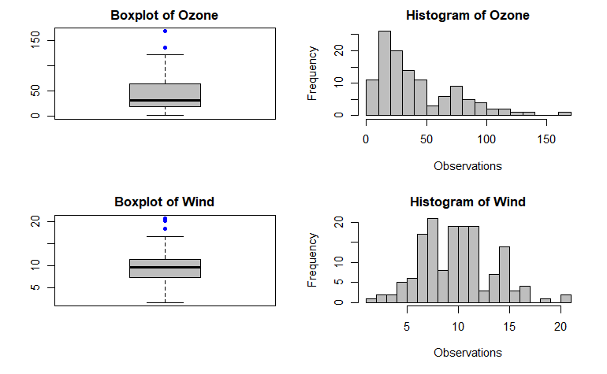

```r
boxplot(airquality$Wind,col = "grey",main = "Boxplot of Wind",outcol="Blue",outpch=19,boxwex=0.7,range = 1.5)
hist(airquality$Wind,col = "grey",main = "Histogram of Wind", xlab = "Observations",breaks = 15)
```

Save the row numbers in a vector:

```r
  # get the values of the outliers
  outliers_ozone <- boxplot(airquality$Ozone, plot = F)$out
  # find the row numbers of the outliers
  index_out <- match(outliers_ozone, airquality$Ozone)
```

`Wind` contains also outliers (see previous boxplots). Add the row number of these outliers to the vector `index_out`

```r
  # get the values of the outliers
  outliers_wind <- boxplot(airquality$Wind, plot = F)$out
  # find the row numbers of the outliers & add them to the vector "index_out"
  index_out <- c(index_out, match(outliers_wind, airquality$Wind))
  index_out
```

```
[1]  62 117   9  18  48
```

Now we remove all the outliers,because they have an effect on the mean and the general distribution:

```r
  # remove outliers
  dataset <- airquality[-index_out,]
```

Check if outliers have been deleted

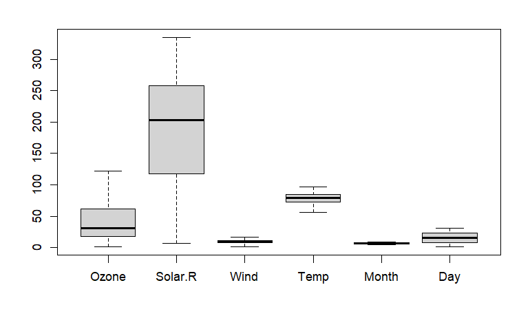

```r
boxplot(dataset)
```

There are no outliers anymore in our dataset.

### Missing values

Before we treat the missing data, it is good to check the amount of missing data.

```r
colSums(is.na(dataset))
```

```
  Ozone Solar.R    Wind    Temp   Month     Day
     37       7       0       0       0       0
```

Now we need to delete all the missing data.

```r
alldata <- na.omit(dataset)
md.pattern(alldata, plot=F)
```

```
 /\     /\
{  `---'  }
{  O   O  }
==>  V <==  No need for mice. This data set is completely observed.
 \  \|/  /
  `-----'

    Ozone Solar.R Wind Temp Month Day
106     1       1    1    1     1   1 0
        0       0    0    0     0   0 0
```

With the function above we deleted all missing values. And we see no missing values in the pattern function. Now we continue with the 106 remaining values.

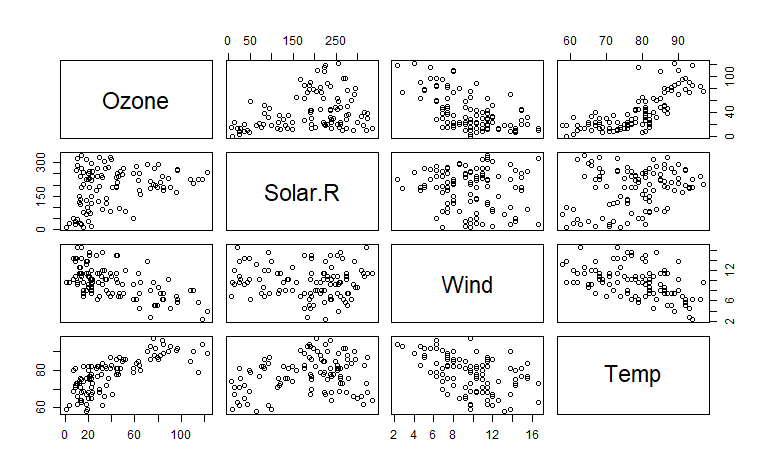

```r
pairs(alldata[,1:4])
```

Within the scatter-plot with the missing values deleted we see a less values but no bad spread like we had seen with the median imputation.

Because we don’t need to normalize the data in this task we continue with developing a linear regression model.

# 4. Split your data: create a training and a test data set

```r
# Create a list of 70% of the rows in the original dataset we can use for training
train_index<-createDataPartition(alldata$Ozone, p =0.70, list = FALSE)

# Select 30% of the data for testing
testing<-alldata[-train_index, ]

# Use the remaining 70% of data to train and validate the models
training <-alldata[train_index, ]
```

With the code above we again did a 70:30 split for training and testing the model.

# 5. Choose & evaluate ML models

```r
# Linear Regression model
set.seed(7)
fit.lm <- train(Ozone~., data=training, method="lm", metric="Rsquared")

fit.lm
```

```
Linear Regression

76 samples
 5 predictor

No pre-processing
Resampling: Bootstrapped (25 reps)
Summary of sample sizes: 76, 76, 76, 76, 76, 76, ...
Resampling results:

  RMSE      Rsquared   MAE
  18.86105  0.6666099  14.65333

Tuning parameter 'intercept' was held constant at a value of TRUE
```

Here, with the same seed for reproduce ability, we do have already a higher Rsquared coefficient than with the median imputation, so deleting the missing values is a better method.

### Have a closer look on the results:

```r
summary (fit.lm)
```

```
Call:
lm(formula = .outcome ~ ., data = dat)

Residuals:
    Min      1Q  Median      3Q     Max
-31.606 -10.499  -2.235   9.228  43.754

Coefficients:
             Estimate Std. Error t value Pr(>|t|)
(Intercept) -78.08385   22.89872  -3.410  0.00108 **
Solar.R       0.06078    0.02338   2.599  0.01138 *
Wind         -3.45421    0.72803  -4.745 1.07e-05 ***
Temp          2.02436    0.28286   7.157 6.47e-10 ***
Month        -2.87245    1.49406  -1.923  0.05860 .
Day           0.33011    0.22914   1.441  0.15415
---
Signif. codes:  0 ‘***’ 0.001 ‘**’ 0.01 ‘*’ 0.05 ‘.’ 0.1 ‘ ’ 1

Residual standard error: 16.77 on 70 degrees of freedom
Multiple R-squared:  0.7224,    Adjusted R-squared:  0.7025
F-statistic: 36.43 on 5 and 70 DF,  p-value: < 2.2e-16
```

We can see the same order when using the `varImp()` function

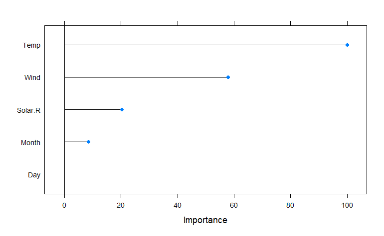

```r
plot(varImp(fit.lm))
```

Above we see the importance of the variables and reduce the model to the 3 parameters with the main influence:

```r
fit.lm1 <- train(Ozone~Solar.R+Wind+Temp, data=training, method="lm", metric="Rsquared")
summary(fit.lm1)
```

```
Call:
lm(formula = .outcome ~ ., data = dat)

Residuals:
    Min      1Q  Median      3Q     Max
-32.987 -11.810  -2.042   9.182  54.099

Coefficients:
             Estimate Std. Error t value Pr(>|t|)
(Intercept) -68.12401   22.70304  -3.001  0.00370 **
Solar.R       0.07331    0.02329   3.148  0.00239 **
Wind         -3.70048    0.72932  -5.074 2.93e-06 ***
Temp          1.69328    0.24874   6.807 2.50e-09 ***
---
Signif. codes:  0 ‘***’ 0.001 ‘**’ 0.01 ‘*’ 0.05 ‘.’ 0.1 ‘ ’ 1

Residual standard error: 17.23 on 72 degrees of freedom
Multiple R-squared:  0.6983,    Adjusted R-squared:  0.6857
F-statistic: 55.54 on 3 and 72 DF,  p-value: < 2.2e-16
```

We see while reducing the variables the sign. level stayed nearly the same.

### Check the prediction Quality

Make predictions on unseen data

```r
predictions<-predict(fit.lm1, testing)
```

Check the distribution of the residuals

```r
# density plot of residuals
residuals <- testing$Ozone - predictions
```

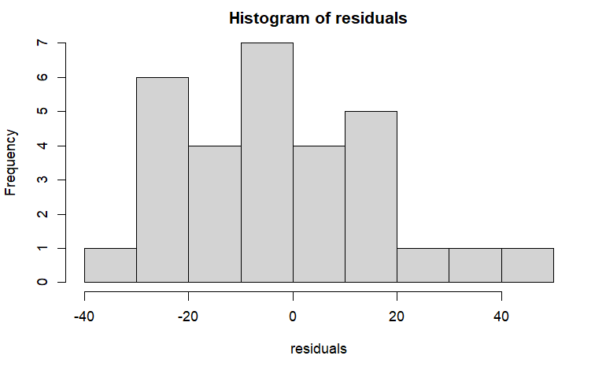

```r
hist(residuals)
```

Coefficient of determination

```r
SSE <- sum(residuals^2)
SST <- sum((testing$Ozone-mean(testing$Ozone))^2)
Rsq <-1-SSE/SST
Rsq
```

```
[1] 0.5701419
```

## Questions/Tasks to be done

2. Remove outliers, impute the missing values with predictive mean matching 5 times (m=5). Keep the data splitting with 70% / 30%.
   - compare the 5 imputing results with each other and select the best model (try to use functions from the `mice package`)
   - compare the best model with the one obtained in today’s class
   - what is your conclusion?

# Data pre-processing

Now for this task 1 we need to:

1. Outlier detection -> and removing
2. Missing value treatment -> PMM
3. Normalization

### Outlier removing

Now we again remove all the outliers,because they have an effect on the mean and the general distribution:

```r
  # remove outliers
  dataset <- airquality[-index_out,]
```

Check if outliers have been deleted

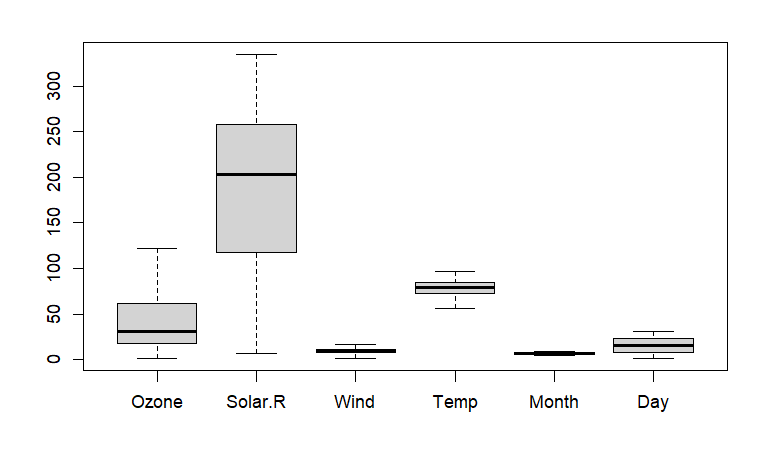

```r
boxplot(dataset)
```

### Missing values and PMM (predictive mean matching)

Now we are using PMM to treat our missing value problem

```r
imputed_data_pmm <- mice(dataset,m=5,maxit=50,method='pmm', seed= 500,printFlag=F)
```

```r
par(mfrow=c(2,3))
boxplot(complete(imputed_data_pmm,1))
boxplot(complete(imputed_data_pmm,2))
```

```r
boxplot(complete(imputed_data_pmm,3))
boxplot(complete(imputed_data_pmm,4))
```

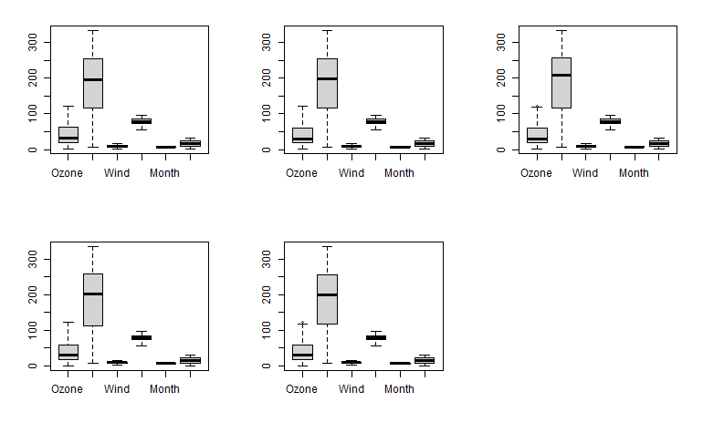

```r
boxplot(complete(imputed_data_pmm,5))
```

In PMM number 3 and 5 we have some outliers in the boxplot so we dont take these. Number 4 has a slightly lower median than our original boxplot. So i continue with PMM number 2 and also, the data are good presented in the hull in the pairs/scatter plot below.

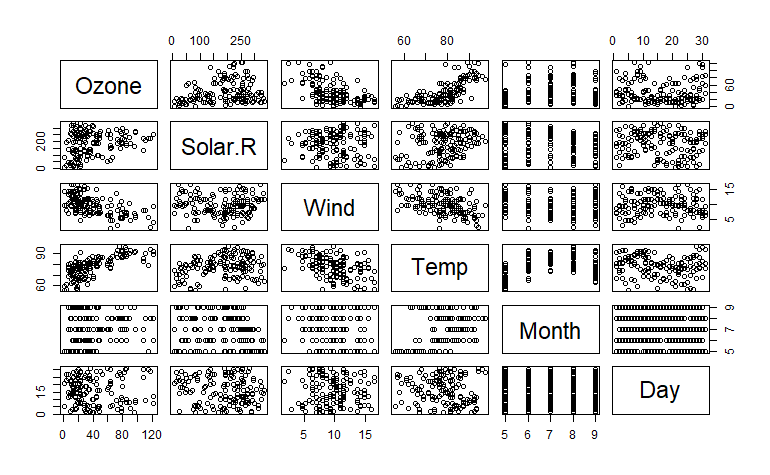

```r
pairs(complete(imputed_data_pmm,2))
```

```
 /\     /\
{  `---'  }
{  O   O  }
==>  V <==  No need for mice. This data set is completely observed.
 \  \|/  /
  `-----'

    Ozone Solar.R Wind Temp Month Day
148     1       1    1    1     1   1 0
        0       0    0    0     0   0 0
```

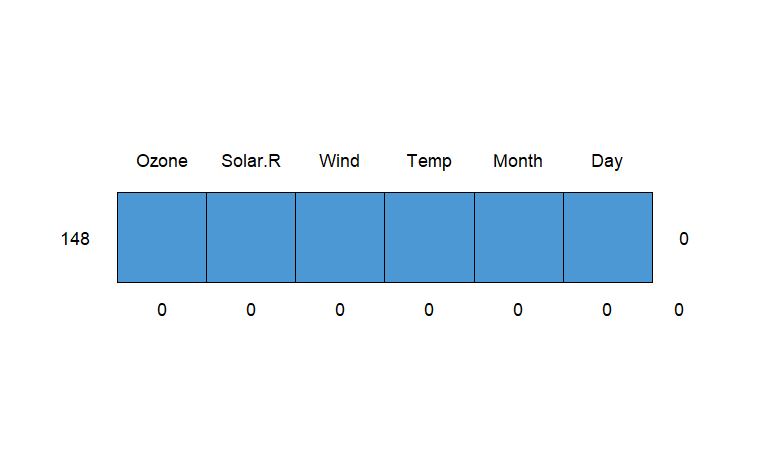

```r
md.pattern((complete(imputed_data_pmm,2)))
```

Now we have 148 values with which we will continue.